# Neural Networks with Keras

For DATA50XX by ctong

## Neural Networks

### Biological Inspiration

Artificial neural networks take inspiration from how the biological neurons process information.

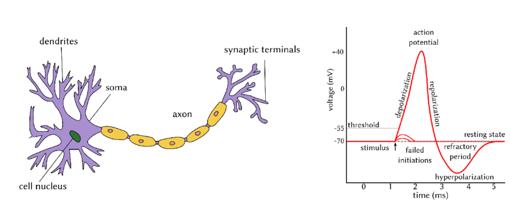

- **Biological analogy:** In the brain, neurons receive signals through their dendrites, process the signals, and pass them along through an axon to other neurons. If the combined incoming signals are strong enough, the neuron produces an **action potential** — an electrical impulse that transmits the signal forward. If the signal is too weak, the neuron does not fire.
- **Artificial version:** In a neural network, an **artificial neuron** (also called a node) receives input values, processes them mathematically, and sends the result to other neurons in the network. The **activation function** plays a role similar to the biological action potential — it decides whether the signal should be passed forward strongly, weakly, or not at all.
- This does not perfectly mimic biology but borrows the idea of many simple units working together to solve complex problems.

### When to Use Neural Networks

Neural networks are most useful when:

- The problem involves **complex patterns** that are hard to capture with traditional statistical models.
- There are **large amounts of data** available for training.
- The relationship between inputs and outputs is **non-linear** and difficult to model with simpler algorithms.

**Examples:**

- Image recognition
- Natural language processing
- Speech recognition
- Predicting outcomes from very high-dimensional datasets

They may be less effective for:

- Small datasets
- Problems where interpretability is more important than predictive accuracy

### Deep Learning

Deep learning is a **specialized branch of machine learning** that uses **neural networks with many layers** to automatically learn complex patterns from data.

- A **basic neural network** might have an input layer, one hidden layer, and an output layer.
- A **deep neural network** has **multiple hidden layers**, sometimes dozens or even hundreds, stacked between the input and output.

**Why “deep” matters:**

- Each layer extracts higher-level features from the data.
- In image recognition, for example, early layers might detect edges, middle layers might detect shapes, and deeper layers might recognize complex objects.
- The more layers there are, the more the network can break down and recombine patterns to capture complexity.

**Relationship between neural networks and deep learning:**

- All deep learning models are neural networks, but not all neural networks are deep learning models.
- Deep learning extends neural networks by using more layers, larger datasets, and often more advanced training techniques.
- The success of deep learning has been driven by improvements in computing power (especially GPUs), larger datasets, and efficient software frameworks like TensorFlow and Keras.

### Artificial Neuron and Forward Propagation

[figure not shown]

**An artificial neuron is made up of:**

1. **Weights** — Numbers that represent the strength or importance of each input. Larger weights mean the input has more influence on the output.
2. **Bias** — A number added to the weighted inputs before applying the activation function. The bias allows the neuron to shift its activation threshold.
   - Without a bias, the neuron’s output depends solely on the weighted sum of the inputs.
   - With a bias, the model can better fit data by adjusting the activation curve up or down.
   - This increases flexibility and helps the network capture patterns more effectively.
3. **Activation Function** — A mathematical function that decides how much signal passes to the next layer. It introduces **non-linearity** so the network can learn complex relationships, rather than just simple straight-line patterns. Common activation functions include:
   - **Sigmoid** — Outputs values between 0 and 1. Useful for binary classification.
   - **Tanh** — Outputs values between -1 and 1. Often works better than sigmoid when inputs can be both positive and negative.
   - **ReLU (Rectified Linear Unit)** — Outputs zero for negative inputs and the input itself for positive values. Popular in hidden layers for its efficiency and ability to reduce certain training problems.
   - **Softmax** — Turns outputs into probabilities that sum to 1, useful for multi-class classification.
4. **Output** — The result after processing the inputs, bias, and activation function. This output can be sent to the next hidden layer or, in the case of the final layer, used as the prediction.

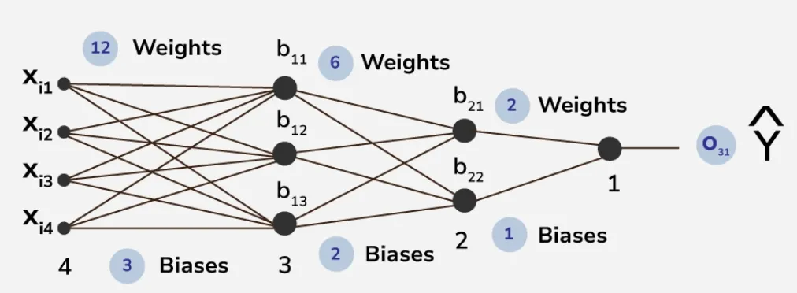

**Forward propagation** is the process by which information moves from artificial neurons in the input layer, through hidden layers, to the output layer.

1. Multiply each input by its corresponding weight.
2. Add them together along with the bias.
3. Pass the result through the activation function to decide how much signal should pass forward.
4. Send the output to the next layer.

### Learning

Learning in a neural network happens in two main phases: the **forward pass** and the **backward pass**.

#### Forward Pass

1. The network takes the input data and sends it forward through the layers.
2. Each neuron processes its inputs using weights, biases, and an activation function.
3. The final output is the network’s prediction for that input.

#### Loss Calculation

- The prediction is compared to the actual correct answer.
- A **loss function** measures the difference between the two. This is essentially the network’s “error score” for that prediction.

#### Backward Pass (Backpropagation)

The backward pass is the process the network uses to figure out **which parts of itself caused the error** and how to adjust them.

1. Starting from the output layer, the network works backwards to see how much each weight and bias influenced the error.
2. This is done using a series of mathematical rules (chain rule of calculus) that break the overall error into smaller contributions from each neuron.
3. The result is a set of **error signals** for every weight and bias in the network, telling us which direction (increase or decrease) would improve performance.

#### Weight and Bias Updates

Once the network knows how each weight and bias contributed to the error, it adjusts them:

- If a weight made the prediction **too high**, it is slightly decreased.
- If a weight made the prediction **too low**, it is slightly increased.
- The size of the adjustment is controlled by a **learning rate**, a small number that prevents changes from being too drastic.

This update process is usually done with an **optimization algorithm**, most commonly **gradient descent** or one of its improved variants (such as Adam). Think of gradient descent like following a slope downhill: the loss function is a “hill,” and the network takes small steps downhill toward the lowest point (minimum error).

#### Repetition and Learning

This forward–backward–update cycle is repeated many times with different training examples.

- Over time, the weights and biases settle into values that produce better and better predictions.
- The goal is to find settings where the network’s overall error is as small as possible for the training data.

### Loss Functions

Loss functions measure how far predictions are from the target values.

- **Mean Squared Error (MSE)** — Common for regression tasks where outputs are numeric.
- **Mean Absolute Error (MAE)** — Similar to MSE but less sensitive to large errors.
- **Binary Cross-Entropy** — Used for binary classification (two classes).
- **Categorical Cross-Entropy** — Used for multi-class classification.
- **Sparse Categorical Cross-Entropy** — A variant of categorical cross-entropy for when class labels are integers rather than one-hot encoded.

Choice of loss function depends on the type of prediction task.

### Overfitting

**Overfitting** happens when a neural network learns the training data **too well**, including its noise and random fluctuations, rather than just the underlying patterns.

- In this case, the network performs very well on the training data but poorly on new, unseen data.
- This means it has memorized the data instead of generalizing from it.

**Why neural networks are prone to overfitting:**

- They often have many parameters (weights and biases), giving them the ability to fit very complex patterns.
- With enough capacity, a network can essentially “remember” the entire training dataset, even if some patterns are irrelevant or misleading.

**Signs of overfitting:**

- Training accuracy continues to improve, but validation accuracy stops improving or starts to decline.
- Loss on the validation set begins to increase while training loss keeps decreasing.

**Ways to mitigate overfitting in neural networks:**

1. **More training data** — A larger dataset provides more variety, making it harder for the network to memorize individual examples.
2. **Early stopping** — Monitor validation performance during training and stop when it stops improving.
3. **Regularization techniques** — Methods that limit how much the model can rely on any single parameter:
   - **L1 and L2 regularization** (weight penalties) discourage very large weights.
4. **Dropout** — Randomly “turns off” some neurons during training so the network does not become overly dependent on specific pathways.
5. **Data augmentation** — For images, this could mean rotating, flipping, or slightly altering them to create variety; for text, it might mean rephrasing or substituting words.
6. **Reducing model complexity** — Using fewer layers or fewer neurons per layer can help if the model is excessively large for the problem.
7. **Batch normalization** — Helps stabilize and speed up training, sometimes reducing overfitting as a side effect.

The key is to balance **model capacity** (its ability to learn complex patterns) with **generalization ability** (its ability to work well on new data).

## Keras

### Installation

If you have not installed Keras and TensorFlow yet, run the following once. This may take several minutes.

```r
# Install Keras interface for R
install.packages("keras")

# Load the Keras library
library(keras)

# Install TensorFlow backend used by Keras (CPU by default)
keras::install_keras()
```

### TensorFlow and Keras

- **TensorFlow:** A powerful open-source framework for building and training machine learning models. It handles the mathematical computations that make neural networks work.
- **Keras:** A high-level interface that makes it easier to design and train neural networks without writing low-level TensorFlow code.
- In R, the **keras** package allows you to use the Keras API directly, while TensorFlow runs the calculations in the background.
- Keras focuses on simplicity and quick experimentation, while TensorFlow provides the flexibility and performance needed for production-scale systems.

*Notes:*

- **Caret** can be used for building (and cross-validating) neural networks by setting the method to `nn` in the `train()` function, but functionality is much more limited compared to what **Keras** offers.
- **Keras 3** is a full rewrite Keras and the most current version.

### Neural Networks supported by Keras

Keras provides several APIs for building models, each suited to different levels of complexity and flexibility.

#### A. Sequential API

Best for models where layers are arranged in a simple, straight stack from input to output.

- **Feedforward Neural Networks (Dense layers)** — Standard choice for tabular data where all features are known in advance.
- **Basic Convolutional Neural Networks (CNNs)** — Often used for image tasks.
  - **Convolution layers** scan over an image with small “filters” or “kernels” that look for specific features such as edges, shapes, or textures. The same filter is applied across the entire image, allowing the network to detect a pattern regardless of its position.
  - **Pooling layers** reduce the size of the data by summarizing regions (often by taking the maximum or average value), which makes the network faster, less prone to overfitting, and better at focusing on the most important information in the image.
- **Basic Recurrent Neural Networks (RNNs)** — Designed for sequential data such as text, speech, or time series.
  - RNNs process one step of the sequence at a time and carry information from previous steps forward in a “hidden state.” This allows the network to use earlier context to influence later predictions. For example, in language modeling, the network can remember the earlier words in a sentence to predict the next word.
- **Simple LSTM or GRU models** — Specialized forms of RNNs that handle long-term dependencies better.
  - **LSTM** stands for *Long Short-Term Memory*. It uses a special “memory cell” and gates that control what information to keep, update, or forget over time, helping to prevent the loss of important context in long sequences.
  - **GRU** stands for *Gated Recurrent Unit*. It works similarly to LSTM but with a simpler design, often requiring fewer computational resources while still handling long-term dependencies effectively.

#### B. Functional API

Allows creation of more complex network structures, including models with multiple inputs, multiple outputs, shared layers, or non-linear paths.

- **Advanced CNNs** — Architectures with branches, skip connections, or merged feature maps (e.g., ResNet-like designs).
- **Hybrid Models** — Combining CNN layers for feature extraction with RNN layers for sequential analysis.
- **Multi-Input or Multi-Output Models** — For cases where you have different types of input data or need multiple predictions from the same network.
- **Autoencoders** — For compression, feature learning, and denoising.
- **Transformer-based Models** — For advanced natural language processing tasks.

#### C. Model Subclassing API

The most flexible approach, used for full control over how layers connect and how data flows. Recommended for research, experimentation, or highly custom models.

- **Generative Adversarial Networks (GANs)** — Where a generator and discriminator network are trained together.
- **Custom Training Loops** — Models with unusual layer arrangements or training steps.
- **Experimental Architectures** — Any design that does not fit well into Sequential or Functional models.

## Demo: Feedforward NN

### Tabular Classification with Iris

```r
# Load required libraries for this lesson
library(keras)    # High-level neural networks API
library(tensorflow) # tensorflow module for building nns
library(tibble)   # Tidy display of small tables
library(dplyr)    # Data wrangling helpers
library(ggplot2)  # Plotting training curves and diagnostics

# Set a seed for reproducibility of operations in R
set.seed(123)
```

```r
# -----------------------------
# 1) DATA PREPARATION
# -----------------------------

# Load the built-in iris dataset into memory
data(iris)

# Select two features to keep the example simple and interpretable
# Using a dplyr pipeline to select Petal.Length and Petal.Width
features <- iris %>% select(Petal.Length, Petal.Width)

# Convert the species factor to integer class indices
# as.integer(.) returns 1,2,3 for the three species
# Subtract 1 so classes are 0,1,2 which Keras expects
labels <- as.integer(iris$Species) - 1L

# Compute the number of unique classes from the labels (should be 3)
num_classes <- length(unique(labels))

# Use one_hot function in tensorflow module to convert each class to
# a vector like [1,0,0], [0,1,0], [0,0,1]
y <- tf$one_hot(indices = labels, depth = num_classes)
y <- as.array(y)

# Convert the features data frame into a numeric matrix for Keras
x <- as.matrix(features)

# Set a seed to make the train/test split reproducible
set.seed(123)

# Count the number of observations (rows)
n <- nrow(x)

# Create a random permutation of the row indices 1..n
# This shuffles the data before splitting to avoid bias
idx <- sample.int(n)

# Take the first 80 percent of indices as the training set
train_idx <- idx[1:floor(0.8 * n)]

# Take the remaining 20 percent as the test set
test_idx  <- idx[(floor(0.8 * n) + 1):n]

# Subset the feature matrix by rows for training and test sets
# The empty column index means "all columns"
# drop = FALSE forces the result to remain a matrix even if there is only one column
x_train <- x[train_idx, , drop = FALSE]
x_test  <- x[test_idx,  , drop = FALSE]

# Subset the one-hot labels to match training and test rows
y_train <- y[train_idx, , drop = FALSE]
y_test  <- y[test_idx,  , drop = FALSE]

# Standardize features using the training set statistics only
# 1) Compute per-column mean and standard deviation on x_train
x_mean <- apply(x_train, 2, mean)
x_sd   <- apply(x_train, 2, sd)

# 2) Scale training and test data with the same mean and sd
# This prevents "information leakage" from the test set
# Scaling them separately using their respective means
# and SDs will inflate our performance
x_train <- scale(x_train, center = x_mean, scale = x_sd)
x_test  <- scale(x_test,  center = x_mean, scale = x_sd)
```

```r
# -----------------------------
# 2) MODEL DEFINITION
# -----------------------------

model_iris <- keras_model_sequential() %>%
  # First hidden layer with 16 neurons; ReLU adds nonlinearity
  layer_dense(units = 16, activation = "relu", input_shape = ncol(x_train)) %>%
  # Dropout randomly disables 20 percent of neurons to reduce overfitting
  layer_dropout(rate = 0.2) %>%
  # Second hidden layer with 8 neurons and ReLU activation
  layer_dense(units = 8, activation = "relu") %>%
  # Output layer with 3 neurons (one per class) and softmax to output probabilities
  layer_dense(units = num_classes, activation = "softmax")

# Configure the learning process:
# - Loss: categorical crossentropy for multi-class classification
# - Optimizer: Adam (an adaptive variant of gradient descent)
# - Metrics: accuracy to monitor performance
model_iris %>% compile(
  loss = "categorical_crossentropy",
  optimizer = optimizer_adam(learning_rate = 0.01),
  metrics = c("accuracy")
)

# Print a layer-by-layer summary with parameter counts and shapes
summary(model_iris)
```

```
## Model: "sequential"
## ________________________________________________________________________________
##  Layer (type)                       Output Shape                    Param #
## ================================================================================
##  dense_2 (Dense)                    (None, 16)                      48
##  dropout (Dropout)                  (None, 16)                      0
##  dense_1 (Dense)                    (None, 8)                       136
##  dense (Dense)                      (None, 3)                       27
## ================================================================================
## Total params: 211 (844.00 Byte)
## Trainable params: 211 (844.00 Byte)
## Non-trainable params: 0 (0.00 Byte)
## ________________________________________________________________________________
```

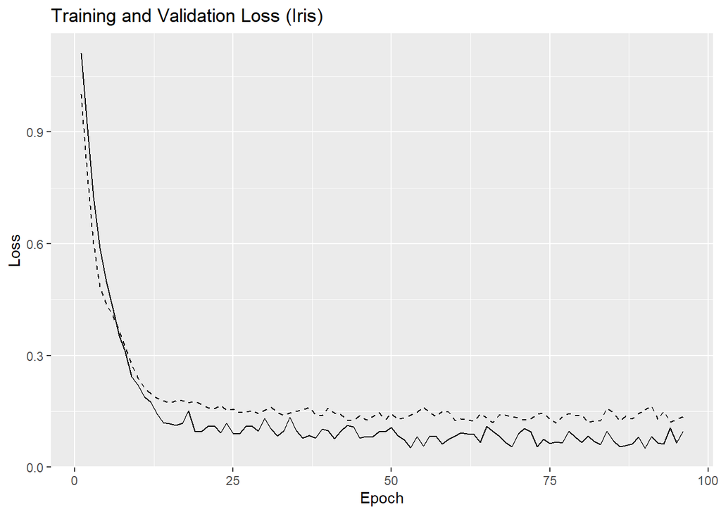

```r
# -----------------------------
# 3) TRAINING
# -----------------------------

# Early stopping monitors validation loss and stops when it stops improving
early_stop <- callback_early_stopping(
  monitor = "val_loss",      # What to watch (validation loss)
  patience = 20,             # Allow 20 epochs without improvement
  restore_best_weights = TRUE# Revert to best-performing epoch
)

# Fit the model on the training data
history_iris <- model_iris %>% fit(
  x = x_train,                # Training inputs
  y = y_train,                # Training targets (one-hot)
  epochs = 200,               # Maximum number of training epochs
  batch_size = 16,            # Samples per gradient update
  validation_split = 0.2,     # Hold out 20 percent of training data for validation
  callbacks = list(early_stop),
  verbose = 0                 # 0 = silent; set to 1 to print per-epoch logs
)

# Prepare a data frame for plotting training and validation loss
df_loss <- data.frame(
  epoch   = seq_along(history_iris$metrics$loss),
  loss    = history_iris$metrics$loss,
  val_loss= history_iris$metrics$val_loss
)

# Plot the training (solid) and validation (dashed) loss over time
ggplot(df_loss, aes(x = epoch)) +
  geom_line(aes(y = loss)) +
  geom_line(aes(y = val_loss), linetype = "dashed") +
  labs(title = "Training and Validation Loss (Iris)",
       x = "Epoch", y = "Loss")
```

**How to read this plot:**  
- The solid line is training loss; the dashed line is validation loss.  
- Both should generally decrease; a widening gap can indicate overfitting.  
- Early stopping restores the weights from the best validation loss point.

```r
# -----------------------------
# 4) EVALUATION AND PREDICTION
# -----------------------------

# Evaluate the model on the test set to obtain loss and accuracy
metrics <- model_iris %>% evaluate(x_test, y_test, verbose = 0)
metrics  # Lower loss and higher accuracy are better
```

```
##       loss   accuracy
## 0.06533296 0.96666664
```

```r
# Predict class probabilities on the test set (each row sums to 1)
probs <- model_iris %>% predict(x_test)
```

```
## 1/1 - 0s - 67ms/epoch - 67ms/step
```

```r
# Convert probability vectors to predicted class indices
# max.col returns the index of the maximum element per row
pred_class <- max.col(probs) - 1L

# Recover the true class indices from one-hot encoded y_test
true_class <- max.col(y_test) - 1L

# Create a confusion matrix to see which classes are confused
table(Predicted = pred_class, Actual = true_class)
```

```
##          Actual
## Predicted  0  1  2
##         0 10  0  0
##         1  0 14  0
##         2  0  1  5
```

**How to interpret the evaluation output:**  
- `metrics` contains test loss and accuracy; these summarize overall performance.  
- The confusion matrix highlights which classes are misclassified; values on the diagonal are correct predictions.

## Demo: Convolutional NN

### Image Recognition with MNIST dataset

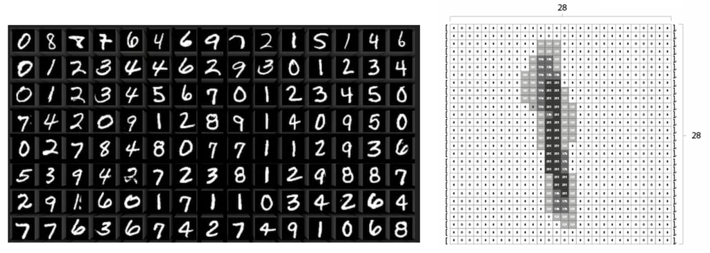

```r
# -------------------------------------------------------------------
# Load required packages
# -------------------------------------------------------------------
library(keras)
library(tensorflow)
```

```r
# -------------------------------------------------------------------
# 1. Load the MNIST dataset
# -------------------------------------------------------------------
# MNIST has 60,000 training and 10,000 test images, each 28x28 grayscale
mnist <- dataset_mnist()

# Training data
x_train <- mnist$train$x   # Shape: (60000, 28, 28)
y_train <- mnist$train$y   # Shape: (60000,)

# Test data
x_test <- mnist$test$x     # Shape: (10000, 28, 28)
y_test <- mnist$test$y     # Shape: (10000,)

# -------------------------------------------------------------------
# 2. Preprocess the data
# -------------------------------------------------------------------

# Reshape from (samples, 28, 28) to (samples, 28, 28, 1) because Keras
# Conv2D expects a "channels" dimension for images
# - Here channels = 1 for grayscale images
x_train <- array_reshape(x_train, c(nrow(x_train), 28, 28, 1))
x_test  <- array_reshape(x_test,  c(nrow(x_test),  28, 28, 1))

# Scale pixel values from [0,255] to [0,1] for faster training
x_train <- x_train / 255
x_test  <- x_test / 255

# # Convert class labels (0–9) to one-hot encoded vectors of length 10
# # Example: label 7 becomes [0,0,0,0,0,0,0,1,0,0]
num_classes <- 10
# y_train <- to_categorical(y_train, num_classes = num_classes)
# y_test  <- to_categorical(y_test,  num_classes = num_classes)

# Labels as integer class indices (0..9)
y_train <- as.integer(mnist$train$y)
y_test  <- as.integer(mnist$test$y)
```

```r
# -------------------------------------------------------------------
# 3. Build the Sequential model
# -------------------------------------------------------------------
# We use a simple CNN (Convolutional Neural Network) for image recognition
model <- keras_model_sequential() %>%

  # First convolutional layer:
  # - 32 filters, each of size 3x3
  # - Activation: ReLU for non-linearity
  # - Input shape: 28x28 pixels, 1 channel
  layer_conv_2d(
    filters = 32, kernel_size = c(3,3), activation = "relu",
    input_shape = c(28, 28, 1)
  ) %>%

  # Max pooling reduces spatial size by taking max in 2x2 windows
  layer_max_pooling_2d(pool_size = c(2,2)) %>%

  # Second convolutional layer with 64 filters
  layer_conv_2d(
    filters = 64, kernel_size = c(3,3), activation = "relu"
  ) %>%

  # Another max pooling step
  layer_max_pooling_2d(pool_size = c(2,2)) %>%

  # Flatten 2D feature maps into 1D vector for dense layers
  layer_flatten() %>%

  # Fully connected dense layer with 128 neurons
  layer_dense(units = 128, activation = "relu") %>%

  # Dropout to prevent overfitting (50% of neurons randomly turned off)
  layer_dropout(rate = 0.5) %>%

  # Output layer: 10 units (one per digit class), softmax for probabilities
  layer_dense(units = num_classes, activation = "softmax")

# -------------------------------------------------------------------
# 4. Compile the model
# -------------------------------------------------------------------
# - Loss: categorical crossentropy (for multi-class classification)
# - Optimizer: Adam (adaptive learning rate)
# - Metric: accuracy (fraction of correct predictions)

# Compile for sparse labels
model %>% compile(
  loss = "sparse_categorical_crossentropy",
  optimizer = optimizer_adam(),
  metrics = "accuracy"
)

# View model architecture summary
summary(model)
```

```
## Model: "sequential_1"
## ________________________________________________________________________________
##  Layer (type)                       Output Shape                    Param #
## ================================================================================
##  conv2d_1 (Conv2D)                  (None, 26, 26, 32)              320
##  max_pooling2d_1 (MaxPooling2D)     (None, 13, 13, 32)              0
##  conv2d (Conv2D)                    (None, 11, 11, 64)              18496
##  max_pooling2d (MaxPooling2D)       (None, 5, 5, 64)                0
##  flatten (Flatten)                  (None, 1600)                    0
##  dense_4 (Dense)                    (None, 128)                     204928
##  dropout_1 (Dropout)                (None, 128)                     0
##  dense_3 (Dense)                    (None, 10)                      1290
## ================================================================================
## Total params: 225034 (879.04 KB)
## Trainable params: 225034 (879.04 KB)
## Non-trainable params: 0 (0.00 Byte)
## ________________________________________________________________________________
```

```r
# -------------------------------------------------------------------
# 5. Train the model
# -------------------------------------------------------------------
history <- model %>% fit(
  x = x_train, y = y_train,               # Training data
  epochs = 5,                              # Number of passes through dataset
  batch_size = 128,                        # Samples per gradient update
  validation_split = 0.2,                  # Hold out 20% for validation
  verbose = 2                              # Show training progress
)
```

```
## 375/375 - 6s - loss: 0.3556 - accuracy: 0.8909 - val_loss: 0.0775 - val_accuracy: 0.9748 - 6s/epoch - 15ms/step
## 375/375 - 5s - loss: 0.1148 - accuracy: 0.9667 - val_loss: 0.0501 - val_accuracy: 0.9851 - 5s/epoch - 14ms/step
## 375/375 - 5s - loss: 0.0848 - accuracy: 0.9749 - val_loss: 0.0473 - val_accuracy: 0.9864 - 5s/epoch - 14ms/step
## 375/375 - 5s - loss: 0.0673 - accuracy: 0.9795 - val_loss: 0.0431 - val_accuracy: 0.9873 - 5s/epoch - 15ms/step
## 375/375 - 6s - loss: 0.0571 - accuracy: 0.9826 - val_loss: 0.0382 - val_accuracy: 0.9887 - 6s/epoch - 15ms/step
```

```r
# -------------------------------------------------------------------
# 6. Evaluate the model on the test set
# -------------------------------------------------------------------
score <- model %>% evaluate(x_test, y_test, verbose = 0)
cat("Test loss:", score[[1]], "\n")
```

```
## Test loss: 0.03067734
```

```r
cat("Test accuracy:", score[[2]], "\n")
```

```
## Test accuracy: 0.99
```

```r
# -------------------------------------------------------------------
# 7. Make predictions
# -------------------------------------------------------------------
# Predict class probabilities for first 10 test images
predictions <- model %>% predict(x_test[1:10,,,])
```

```
## 1/1 - 0s - 65ms/epoch - 65ms/step
```

```r
# Convert probabilities to predicted class indices
predicted_classes <- apply(predictions, 1, which.max) - 1  # zero-based index

cat("Predicted classes:", predicted_classes, "\n")
```

```
## Predicted classes: 7 2 1 0 4 1 4 9 5 9
```

```r
y_test[1:10]
```

```
##  [1] 7 2 1 0 4 1 4 9 5 9
```

### Comments

- ‘history’ object contains training/validation loss and accuracy per epoch
- ‘score’ gives final loss and accuracy on the unseen test set
- ‘predictions’ is a matrix: each row sums to 1 (probabilities across digits)
- ‘predicted_classes’ is the model’s guess for each sample